# CD705 Statistical Data Analysis with R Week 6.2: Low-Level Graphics in R

Alexey Chernov

11 November 2026

Sometimes, when we want to visualise something unusual, we may need to use very low-level tools.

As an example, let’s take the positions of planets of the Solar System with respect to Earth on 11 November 2026, 14:00 GMT, from http://cosinekitty.com/solar_system.html:

```r
print(planets <- read.csv("planets2026.csv"))
```

```
##      Name          X          Y          Z   Distance   Radius
## 1     Sun -0.6469959 -0.7494010  0.0000000  0.9900533 109.3000
## 2 Mercury -0.6226749 -0.4432168  0.0226125  0.7646414   0.3829
## 3   Venus -0.2892629 -0.1226470 -0.0122577  0.3144290   0.9499
## 4   Earth  0.0000000  0.0000000  0.0000000  0.0000000   1.0000
## 5    Mars -1.0840343  0.7946763  0.0429800  1.3448004   0.5320
## 6 Jupiter -4.3695463  3.0478878  0.0676148  5.3279571  10.9700
## 7  Saturn  8.5615680  1.3086568 -0.4015598  8.6703103   9.1400
## 8  Uranus  8.1327477 16.5820564 -0.0494999 18.4691264   3.9810
## 9 Neptune 29.1593144  0.9548130 -0.7179443 29.1837751   3.8650
```

The distances and coordinates are in astronomical units (1AU = 149 597 870 700 m, or the mean distance between Earth and Sun). The unit for the radii is the radius of Earth.

Let’s start with a minimal plot:

```r
plot.new()
plot.window(xlim=c(0,1),ylim=c(0,1))
plot.xy(xy.coords(x=0.5,y=0.5),type="p")
```

[output not shown]

Higher-level functions have a lot of defaults:

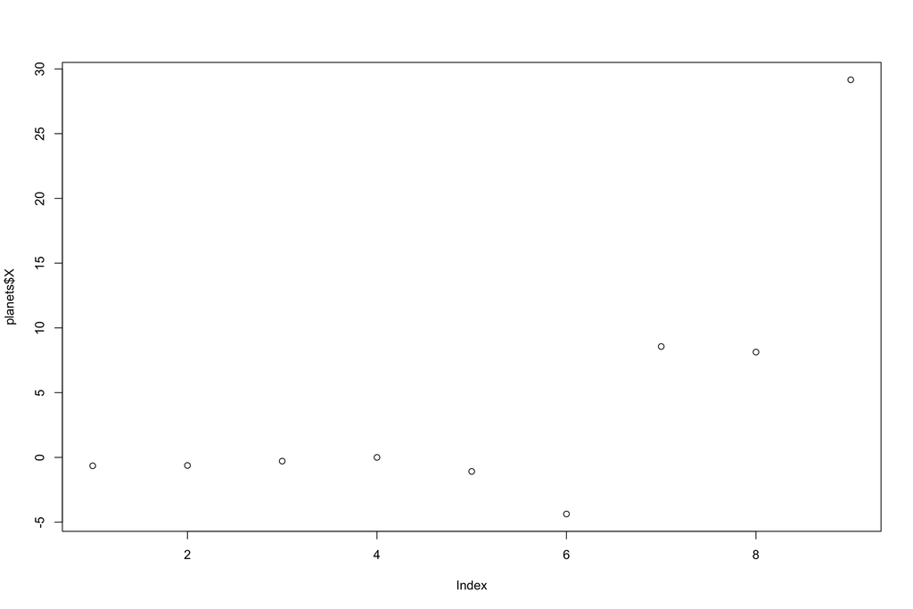

```r
plot.default(planets$X)
```

We need to look at the data and decide what we want to plot:

```r
summary(planets)
```

|  | Name | X | Y | Z | Distance | Radius |
| --- | --- | --- | --- | --- | --- | --- |
|  | Length :9 | Min. :-4.3695 | Min. :-0.7494 | Min. :-0.71794 | Min. : 0.0000 | Min. : 0.3829 |
|  | N.unique :9 | 1st Qu.:-0.6470 | 1st Qu.:-0.1226 | 1st Qu.:-0.04950 | 1st Qu.: 0.7646 | 1st Qu.: 0.9499 |
|  | N.blank :0 | Median :-0.2893 | Median : 0.7947 | Median : 0.00000 | Median : 1.3448 | Median : 3.8650 |
|  | Min.nchar:3 | Mean : 4.3157 | Mean : 2.3748 | Mean :-0.11645 | Mean : 7.2295 | Mean : 15.5690 |
|  | Max.nchar:7 | 3rd Qu.: 8.1327 | 3rd Qu.: 1.3087 | 3rd Qu.: 0.02261 | 3rd Qu.: 8.6703 | 3rd Qu.: 9.1400 |
|  | NA | Max. :29.1593 | Max. :16.5821 | Max. : 0.06761 | Max. :29.1838 | Max. :109.3000 |

The Z coordinate seems less informative in comparison, so we will ignore it instead of choosing some more complicated projection.

Prepare the canvas using some mid-level graphics (here `plot` is the same as `plot.default`):

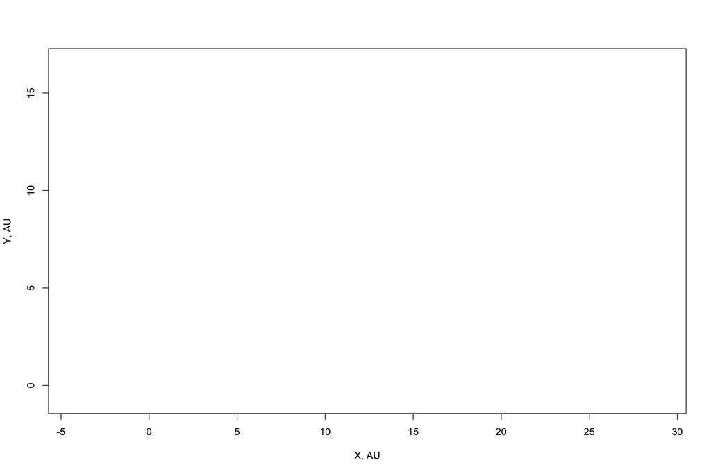

```r
xrange <- range(planets$X)
yrange <- range(planets$Y)
plot(x=NULL,xlim=xrange,ylim=yrange,xlab="X, AU",ylab="Y, AU")
```

Not quite square! We need to set a graphical parameter:

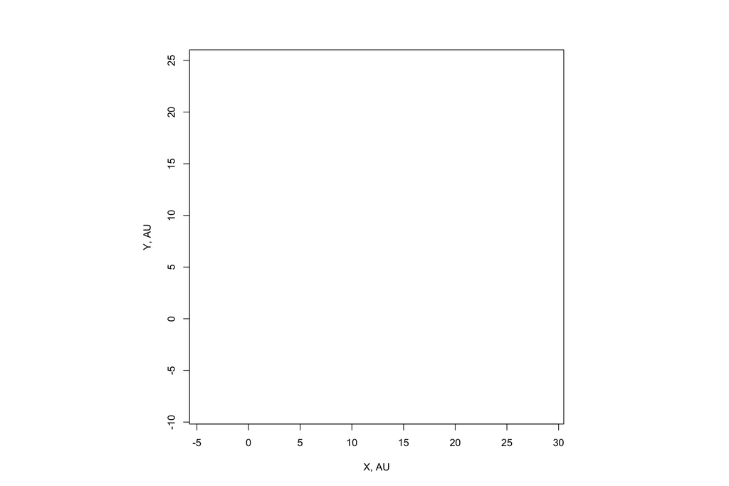

```r
par(pty="s")
plot(x=NULL,xlim=xrange,ylim=yrange,xlab="X, AU",ylab="Y, AU",asp=1)
```

Some extra change:

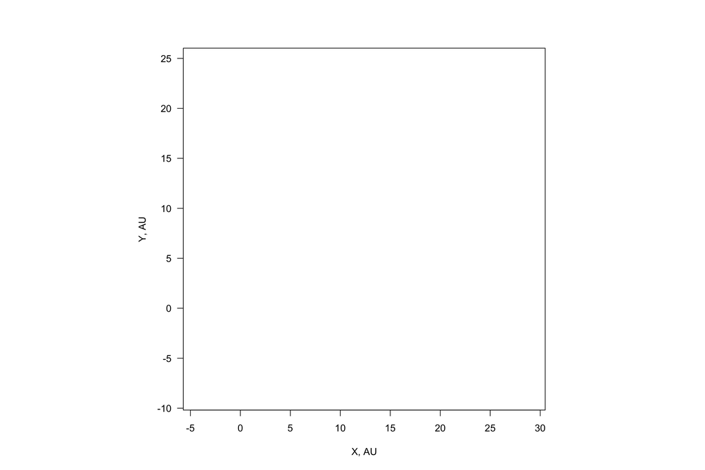

```r
par(pty="s")
plot(x=NULL,xlim=xrange,ylim=yrange,xlab="X, AU",ylab="Y, AU",asp=1,las=1)
```

```r
# las=1 write labels on the vertical axis horizonally
```

Now we can add the points for planets:

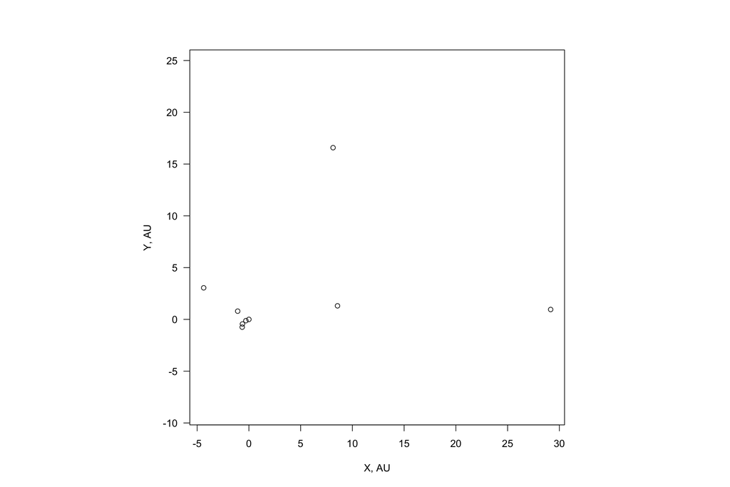

```r
par(pty="s")
plot(x=NULL,xlim=xrange,ylim=yrange,xlab="X, AU",ylab="Y, AU",asp=1,las=1)
points(planets$X,planets$Y)
```

The points are unrecognisable. Let’s add some visual attributes: the colours are approximately the real colours of the planets, the shapes emphasise the most important planets, Sun and Earth, and the point sizes are proportional to the planet radii in the *logarithmic scale*.

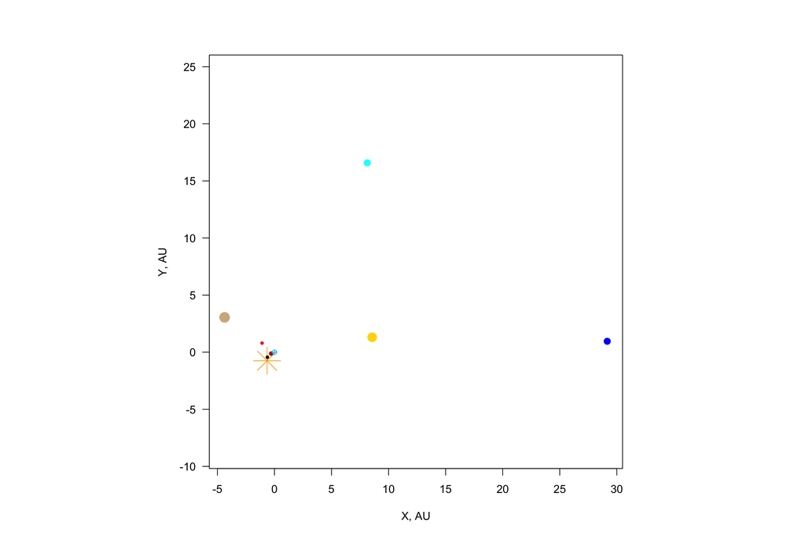

```r
planet.colours <- c("orange","black","brown","deepskyblue","red","tan","gold","cyan","blue")
planet.shapes <- c(8,16,16,10,16,16,16,16,16)
planet.sizes <- round(log(planets$Radius + 2)*0.8,1)
par(pty="s")
plot(x=NULL,xlim=xrange,ylim=yrange,xlab="X, AU",ylab="Y, AU",asp=1,las=1)
points(planets$X,planets$Y,
       col = planet.colours,
       pch = planet.shapes,
       cex = planet.sizes)
```

Add a legend and title:

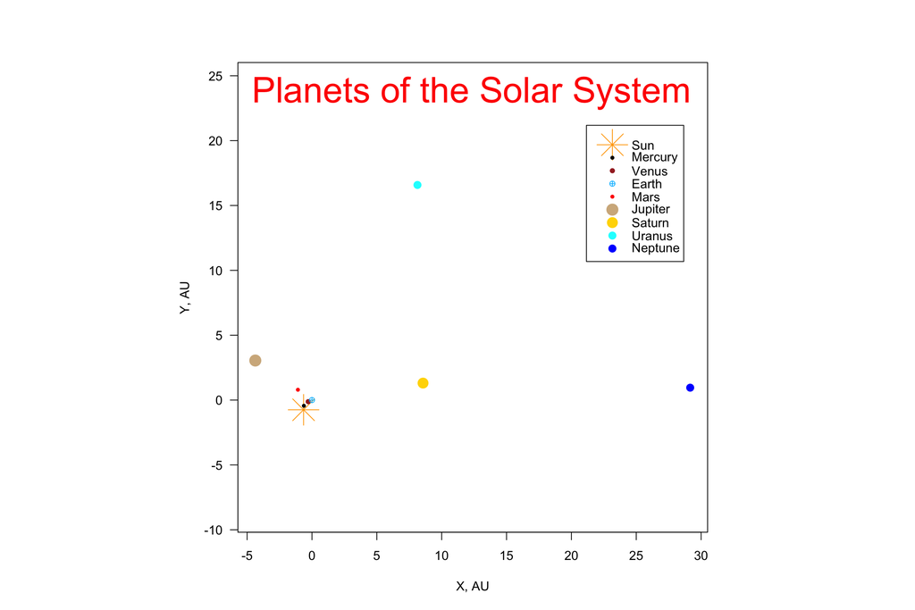

```r
par(pty="s")
plot(x=NULL,xlim=xrange,ylim=yrange,xlab="X, AU",ylab="Y, AU",asp=1,las=1)
points(planets$X,planets$Y,
       col = planet.colours,
       pch = planet.shapes,
       cex = planet.sizes)

# title
title.bottom <- mean(yrange)+0.5*(xrange[2]-xrange[1])-1
text(x=-xrange[1]-9,y=title.bottom,
     labels="Planets of the Solar System",adj=0,cex=2.8,col="red")

# legend
legend.right <- xrange[2] - 0.5
rect(xleft = legend.right - 7.5, ybottom = title.bottom - 4 - nrow(planets),
     xright = legend.right, ytop = title.bottom - 2.5)
points(x=rep(legend.right-5.5,nrow(planets)),y=title.bottom - 3 - (1:nrow(planets)),
       col = planet.colours,
       pch = planet.shapes,
       cex = planet.sizes)
text(x=rep(legend.right-4,nrow(planets)),y=title.bottom - 3 - (1:nrow(planets)),
     labels=planets$Name,adj=0)
```

The positions of the title and legend were found experimentally.

We can also save the picture as a pdf file:

```r
pdf("planets.pdf",width=9,height=9)
par(pty="s")
plot(x=NULL,xlim=xrange,ylim=yrange,xlab="X, AU",ylab="Y, AU",asp=1,las=1)
points(planets$X,planets$Y,
       col = planet.colours,
       pch = planet.shapes,
       cex = planet.sizes)

# title
title.bottom <- mean(yrange)+0.5*(xrange[2]-xrange[1])-1
text(x=-xrange[1]-2,y=title.bottom,
     labels="Planets of the Solar System",adj=0,cex=2.8,col="red")

# legend
legend.right <- xrange[2] - 0.5
rect(xleft = legend.right - 7.5, ybottom = title.bottom - 4 - nrow(planets),
     xright = legend.right, ytop = title.bottom - 2.5)
points(x=rep(legend.right-5.5,nrow(planets)),y=title.bottom - 3 - (1:nrow(planets)),
       col = planet.colours,
       pch = planet.shapes,
       cex = planet.sizes)
text(x=rep(legend.right-4,nrow(planets)),y=title.bottom - 3 - (1:nrow(planets)),
     labels=planets$Name,adj=0)
dev.off()
```

Low-level graphics require a lot of manual adjustments, and it is quite inconvenient if you need to change something. For example, several years ago I decided to show 9 planets instead of 7 I showed the year before. Compare the code above with the following code and notice how many tweaks of graphical coordinates were necessary:

```r
planets <- read.csv("planets2021.csv")
par(pty="s")
plot(x=NULL,xlim=c(-10,10),ylim=c(-10,10),xlab="X, AU",ylab="Y, AU",asp=1,las=1)
points(planets$X,planets$Y,
       col = planet.colours,
       pch = planet.shapes,
       cex = planet.sizes)
points(x=rep(7,nrow(planets)),y=9:3,
       col = planet.colours,
       pch = planet.shapes,
       cex = planet.sizes)
text(x=rep(8,nrow(planets)),y=9:3,labels=planets$Name,adj=0)
rect(xleft=5,ybottom=2,xright=10.5,ytop=10)
text(x=-10,y=9,labels="Planets of",adj=0,cex=3,col="red")
text(x=-10,y=7,labels="the Solar System",adj=0,cex=3,col="red")
```

### Optional Exercise

Use low-level R graphics to draw a clock similar to the picture:

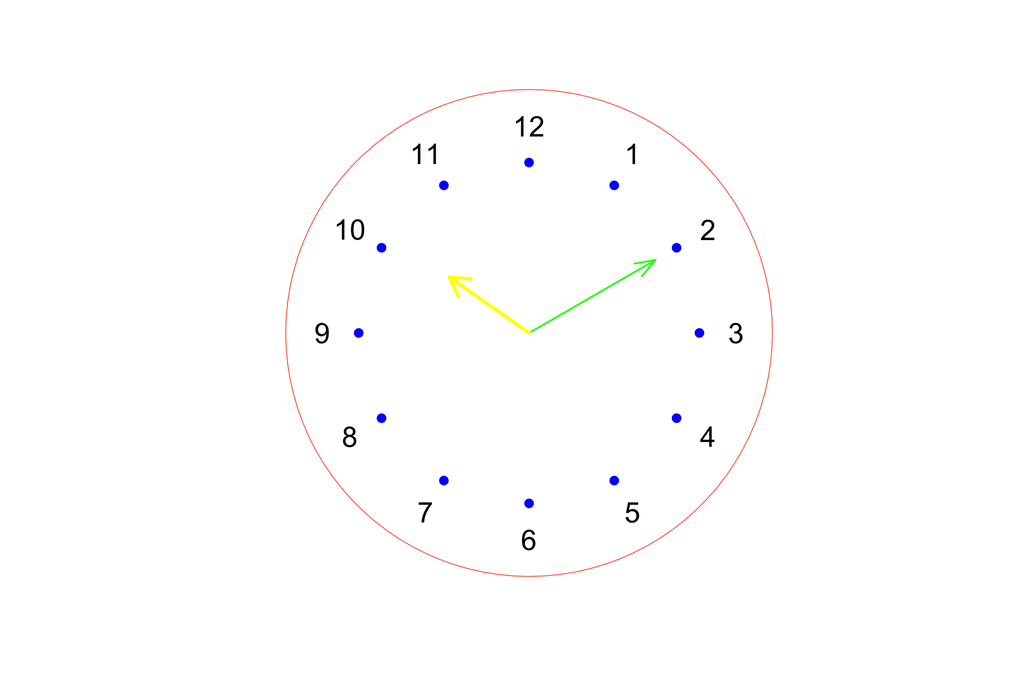

You may find functions `arrows()` and `plotrix::draw.circle()` helpful.

Then use functions `Sys.time()` and `format()` to show the current time in your clock.